# Congressistas no Twitter

Grupo: José Ivan Silva, João Menezes, Thiago Montenegro

```r
atividade = read_projectdata()
validos = atividade %>%
  filter(!is.na(seguidores))

glimpse(validos)
```

```
## Observations: 370
## Variables: 19
## $ id_parlamentar        <chr> "204528", "178836", "160559", "204545", "2…
## $ casa                  <chr> "câmara", "câmara", "câmara", "câmara", "c…
## $ nome_eleitoral        <chr> "ADRIANA VENTURA", "ALAN RICK", "ALCEU MOR…
## $ partido               <chr> "NOVO", "DEM", "MDB", "PSL", "PT", "PSL", …
## $ UF                    <chr> "SP", "AC", "RS", "MG", "SP", "SP", "SP", …
## $ twitter               <chr> "adrianasounovo", "Alan_Rick", "Alceu_More…
## $ seguidores            <dbl> 4652, 3983, 6370, 464, 6447, 161745, 1134,…
## $ segue                 <dbl> 315, 995, 434, 267, 3253, 2015, 140, 1035,…
## $ n_proprio             <dbl> 99, 49, 214, 39, 346, 830, 58, 485, 1, 201…
## $ n_retweet             <dbl> 9, 1, 30, 4, 100, 169, 15, 204, 1, 95, 45,…
## $ engaj_total           <dbl> 7090, 4286, 6852, 10231, 69348, 566011, 30…
## $ engaj_total_proprio   <dbl> 6701, 284, 2239, 186, 47967, 320063, 23, 8…
## $ engaj_total_retweet   <dbl> 389, 4002, 4613, 10045, 21381, 245948, 7, …
## $ engaj_mediano         <dbl> 26.5, 4.0, 8.0, 4.0, 16.5, 134.0, 0.0, 49.…
## $ engaj_mediano_proprio <dbl> 22.5, 4.0, 8.0, 4.0, 12.0, 60.0, 0.0, 27.0…
## $ engaj_mediano_retweet <dbl> 0.0, 0.0, 0.0, 0.0, 0.0, 0.0, 0.0, 0.0, 0.…
## $ engaj_max             <dbl> 1031, 4002, 4227, 8171, 12335, 20348, 4, 3…
## $ engaj_max_proprio     <dbl> 1031, 38, 136, 14, 12335, 7271, 4, 3643, 1…
## $ engaj_max_retweet     <dbl> 99, 4002, 4227, 8171, 8623, 20348, 2, 3302…
```

## Quais as UF onde seus parlamentares mais e menos tuítam tuítes próprios?

Nessa análise utilizaremos boxplots para vermos a distribuição dos tuítes próprios dos parlamentares por estado. O boxplot provê uma boa vizualização para o que queremos enxegar.

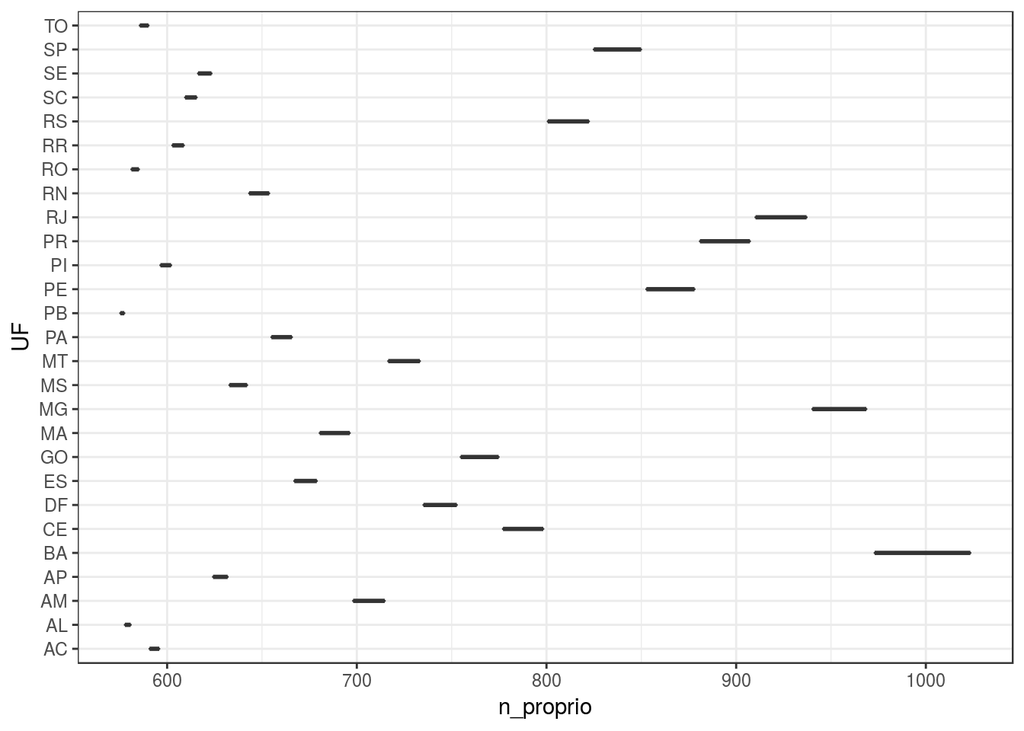

```r
atividade %>% ggplot(aes(x = n_proprio, y = UF)) + geom_boxplot()
```

Como podemos observar, a Bahia e Minas Gerais são os estados brasileiros onde seus parlamentares mais tuítam tuítes próprios. Essas UFs são grandes colégios eleitorais e, geralmente, o Twitter acaba por ser um meio eficaz pra se comunicar com os eleitores desses estados. Em contrapartida, temos a baixa participação dos parlamentares da Paraíba e Alagoas, empatados em último lugar entre os parlamentares que menos tuítam. UFs essas que são colégios eleitorais pequenos e da região que menos possui acesso a internet (apenas 37,2% da população). Os parlamentares devem se utilizar de outros meios para se comunicar com seus eleitores.

## Dos cinco principais estados onde seus parlamentares mais tuítam quais os parlamentares que mais retuítam?

Os cinco estados onde seus parlamentares mais tuítam tuítes próprios foram, respectivamente: Bahia, Minas Gerais, Rio de Janeiro, Paraná e Pernambuco.

Na análise, utilizaremos a distribuição dos boxplots para observarmos a mediana de retuítes para cada estado especificado.

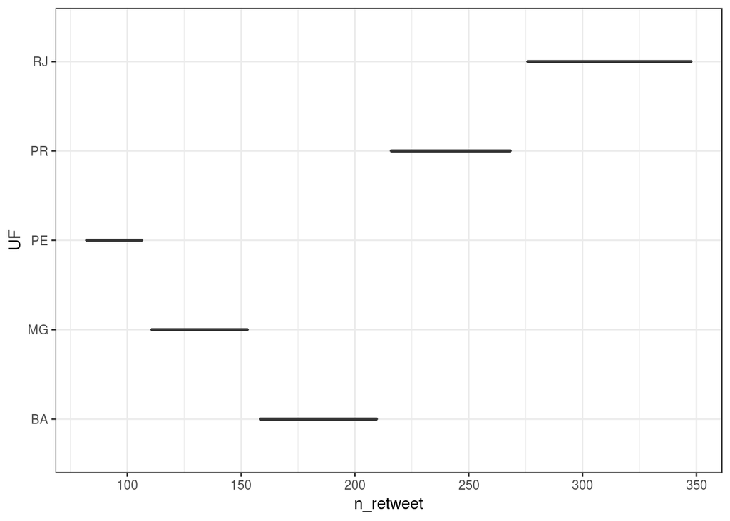

```r
atividade %>% filter(UF == "BA" | UF == "MG" | UF == "RJ" | UF == "PR" | UF == "PE") %>%
  ggplot(aes(x = n_retweet, y = UF)) + geom_boxplot()
```

Como podemos observar, o Rio de Janeiro é o estado dentre aqueles em que seus parlamentares mais tuítam tuítes próprios que mais retuítam, seguidos do Paraná. A ordem respectiva é a seguinte: Rio de Janeiro, Paraná, Bahia, Minas Gerais e Pernambuco.

## Dos cinco principais estados onde seus parlamentares mais tuítam quais os parlamentares que mais geram engajamento nos seus tuítes próprios?

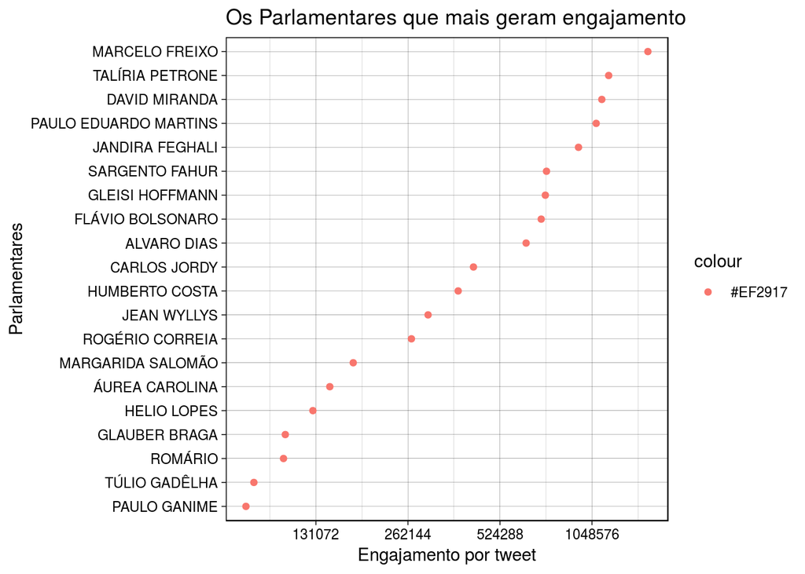

```r
    engajamento_proprio = validos %>%
         filter(UF == 'BH' | UF == 'MG' | UF == 'RJ' | UF == 'PR' | UF == 'PE') %>%
          select(nome_eleitoral, engaj_total_proprio)

    engajamento_proprio %>%
        arrange(-engaj_total_proprio) %>%
        slice(0:20) %>%
        ggplot(aes(x = reorder(nome_eleitoral, engaj_total_proprio), y = engaj_total_proprio, color = "#EF2917")) +
        geom_point() +
        coord_flip() +
        scale_y_continuous(trans  = 'log2') +
        ggtitle('Os Parlamentares que mais geram engajamento') +
        xlab('Parlamentares') +
        ylab('Engajamento por tweet') +
        theme_linedraw()
```

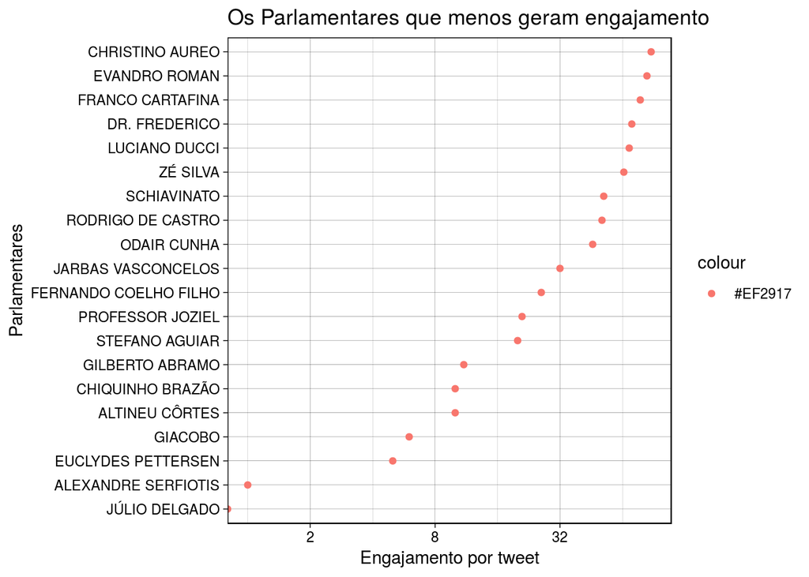

```r
    engajamento_proprio %>%
        arrange(engaj_total_proprio) %>%
        slice(0:20)  %>%
        ggplot(aes(x = reorder(nome_eleitoral, engaj_total_proprio), y = engaj_total_proprio, color = "#EF2917")) +
        geom_point() +
        coord_flip() +
        scale_y_continuous(trans  = 'log2') +
        ggtitle('Os Parlamentares que menos geram engajamento') +
        xlab('Parlamentares') +
        ylab('Engajamento por tweet') +
        theme_linedraw()
```

Percebemos a partir do gráfico acima, que os parlamentares que mais geram engajamento em relação aos seus próprios tweets são Marcelo Freixo, Talíra Petrone, David Miranda, Paulo Eduardo Martins dentre outros, já os parlamentares que menos geram engajamento baseado em seus tuítes próprios são Júlio Delgado, Alexandre Serfiotis e Euclydes Pettersen, dentre outros.

## Quais os partidos onde seus parlamentares possui mais ou menos seguidores?

Tenho a impressão de que os partidos com mais representantes eleitos tendem a ser os partidos que de uma maneira geral vão acumular mais seguidores.

Nessa análise iremos observar o número de seguidores de cada parlamentar de cada partido para aí sim termos alguma conclusão se o número de representantes traz consigo a fama e o reconhecimento na rede social.

```r
partidos_seg = validos %>%
  filter(partido != "S/Partido" & partido != "PRP" & partido != "PMN") %>%
  select(seguidores, partido)

glimpse(partidos_seg)
```

```
## Observations: 367
## Variables: 2
## $ seguidores <dbl> 4652, 3983, 6370, 464, 6447, 161745, 1134, 147085, 88…
## $ partido    <chr> "NOVO", "DEM", "MDB", "PSL", "PT", "PSL", "DEM", "PT"…
```

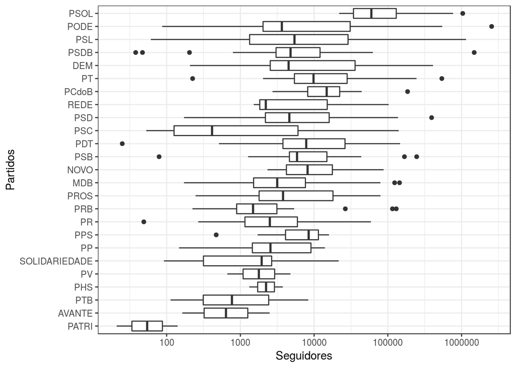

```r
partidos_seg %>%
  ggplot(aes(x = reorder(partido, seguidores), y = seguidores)) +
  geom_boxplot() +
  scale_y_log10() +
  coord_flip() +
  labs(x = "Partidos",
       y = "Seguidores")
```

A partir da visualização criada é possível perceber que realmente, como esperávamos, partidos com grande número de representantes atuantes tem de maneira geral grande quantidade de seguidores no Twitter, porém o líder é incomum. O PSOL é o partido com mais seguidores mesmo tendo bem menos parlamentares do que o PT e o PSL, por exemplo.

## Entre os maiores partidos, qual a relação entre seguidores e engajamento para cada parlamentar?

Acredito que, entre os maiores partidos, quanto mais aumente o número de seguidores de um parlamentar maior será o seu engajamento.

Nessa análise iremos observar os três maiores partidos encontrados na análise passada para analisar, comparar e procurar algum padrão entre a quantidade de seguidores e engajamento total dos parlamentares.

```r
maior_partido = validos %>%
  filter(partido == "PSOL" | partido == "PODE" | partido == "PSL") %>%
  select(seguidores, engaj_total, partido)

glimpse(maior_partido)
```

```
## Observations: 60
## Variables: 3
## $ seguidores  <dbl> 464, 161745, 3318, 33960, 8168, 81544, 7575, 103029,…
## $ engaj_total <dbl> 10231, 566011, 56, 233521, 306591, 1893839, 46227, 3…
## $ partido     <chr> "PSL", "PSL", "PODE", "PSOL", "PODE", "PSL", "PSL", …
```

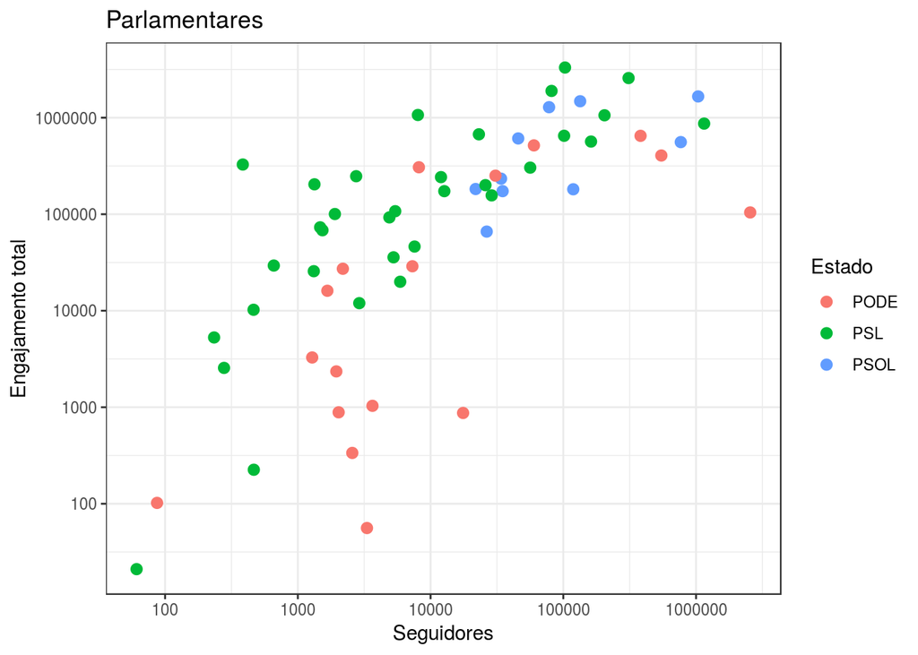

```r
maior_partido %>%
  ggplot(aes(x = seguidores, y = engaj_total, color = partido)) +
  geom_point(size = 2.5) +
  labs(title = "Parlamentares",
       x = "Seguidores",
       y = "Engajamento total",
       color = "Estado") +
  scale_x_log10() +
  scale_y_log10()
```

Como esperado, realmente existe um certo padrão, com o crescimento dos seguidores do parlamentar também cresce o engajamento obtido por ele, de uma maneira geral. Entretanto há dois casos que chamam atenção, onde um parlamentar apresenta grande engajamento e pouco seguidor e outro apresenta o contrário.

```r
parla_psl = validos %>%
  filter(partido == "PSL") %>%
  filter(engaj_total > 100000 & seguidores < 1000) %>%
  select(casa, nome_eleitoral, partido, seguidores, engaj_total)

parla_pode = validos %>%
  filter(partido == "PODE") %>%
  filter(engaj_total > 100000 & seguidores > 1000000) %>%
  select(casa, nome_eleitoral, partido, seguidores, engaj_total)

glimpse(parla_psl)
```

```
## Observations: 1
## Variables: 5
## $ casa           <chr> "câmara"
## $ nome_eleitoral <chr> "NEREU CRISPIM"
## $ partido        <chr> "PSL"
## $ seguidores     <dbl> 385
## $ engaj_total    <dbl> 327142
```

```r
glimpse(parla_pode)
```

```
## Observations: 1
## Variables: 5
## $ casa           <chr> "senado"
## $ nome_eleitoral <chr> "ROMÁRIO"
## $ partido        <chr> "PODE"
## $ seguidores     <dbl> 2558401
## $ engaj_total    <dbl> 104345
```

Esses parlamentares são Nereu Crispim, deputado do PSL, e Romário, senador do PODE, um com altíssimo engajamento e pouquíssimo seguidores o outro sendo o parlamentar com mais seguidores e engajamento relativamente baixo, respectivamente.